# P8130 - Homework 2

Mingkuan Xu

```r
library(tidyverse)
```

## Problem 1

#### Part A - The Mr. Trash Wheel sheet

Load trash wheel data, remove useless columns and take a quick look.

```r
trash_wheel_data =
  readxl::read_excel(
    path="data/Trash-Wheel-Collection-Totals-7-2020-2.xlsx",
    sheet="Mr. Trash Wheel",
    skip=1) %>%
  janitor::clean_names()
skimr::skim(trash_wheel_data)
```

[output not shown]

We find useless columns x15, x16, and x17; remove them. Also we omit rows that do not include dumpster-specific data as instructed. Finally we round the number of sports balls to the nearest integer as instructed.

```r
trash_wheel_data =
  select(trash_wheel_data,-x15,-x16,-x17) %>%
  drop_na(dumpster) %>%
  mutate(sports_balls = round(sports_balls))

head(trash_wheel_data)
```

```
## # A tibble: 6 × 14
##   dumpster month  year date                weight_tons volume_cubic_yards
##   <chr>    <chr> <dbl> <dttm>                    <dbl>              <dbl>
## 1 1        May    2014 2014-05-16 00:00:00        4.31                 18
## 2 2        May    2014 2014-05-16 00:00:00        2.74                 13
## 3 3        May    2014 2014-05-16 00:00:00        3.45                 15
## 4 4        May    2014 2014-05-17 00:00:00        3.1                  15
## 5 5        May    2014 2014-05-17 00:00:00        4.06                 18
## 6 6        May    2014 2014-05-20 00:00:00        2.71                 13
## # … with 8 more variables: plastic_bottles <dbl>, polystyrene <dbl>,
## #   cigarette_butts <dbl>, glass_bottles <dbl>, grocery_bags <dbl>,
## #   chip_bags <dbl>, sports_balls <dbl>, homes_powered <dbl>
```

#### Part B - Precipitation data for 2018 and 2019

We read the precipitation data for 2018 & 2019, drop useless rows, and bind them together.

```r
precipitation_2018_data =
  readxl::read_excel(
    path="data/Trash-Wheel-Collection-Totals-7-2020-2.xlsx",
    sheet="2018 Precipitation",
    skip=1) %>%
  janitor::clean_names() %>%
  drop_na(month) %>%
  mutate(year=2018) %>%
  relocate(year)

precipitation_2019_data =
  readxl::read_excel(
    path="data/Trash-Wheel-Collection-Totals-7-2020-2.xlsx",
    sheet="2019 Precipitation",
    skip=1) %>%
  janitor::clean_names() %>%
  drop_na(month) %>%
  mutate(year=2019) %>%
  relocate(year)

precipitation_data =
  bind_rows(precipitation_2018_data,precipitation_2019_data) %>%
  mutate(month = month.name[month])

head(precipitation_data)
```

```
## # A tibble: 6 × 3
##    year month    total
##   <dbl> <chr>    <dbl>
## 1  2018 January   0.94
## 2  2018 February  4.8
## 3  2018 March     2.69
## 4  2018 April     4.69
## 5  2018 May       9.27
## 6  2018 June      4.77
```

#### Part C - Summary

For the precipitation data, we collected year, month, precipitation. Over the 24 months of collected data from years 2018, 2019, we observe a mean of 4.345 inches and median of 3.745 inches per month. The total precipitation for year 2018 is 70.33 inches; the total precipitation for year 2019 is 33.95 inches.

## Problem 2

#### Part A - Preprocess pols-month.csv

```r
pols_data =
  read_csv(file = "data/pols-month.csv",show_col_types = FALSE) %>%
  separate(mon,c("year","month","day"),"-") %>% # Separate date info
  mutate(month = month.name[as.integer(month)]) %>% # Transform to month names
  mutate(president = ifelse(prez_dem==0,"gop","dem")) %>% # Create column president
  select(-day,-prez_dem,-prez_gop) # Remove useless columns

head(pols_data)
```

```
## # A tibble: 6 × 9
##   year  month    gov_gop sen_gop rep_gop gov_dem sen_dem rep_dem president
##   <chr> <chr>      <dbl>   <dbl>   <dbl>   <dbl>   <dbl>   <dbl> <chr>
## 1 1947  January       23      51     253      23      45     198 dem
## 2 1947  February      23      51     253      23      45     198 dem
## 3 1947  March         23      51     253      23      45     198 dem
## 4 1947  April         23      51     253      23      45     198 dem
## 5 1947  May           23      51     253      23      45     198 dem
## 6 1947  June          23      51     253      23      45     198 dem
```

#### Part B - Preprocess snp.csv

```r
snp_data =
  read_csv(file = "data/snp.csv",show_col_types = FALSE) %>%
  separate(date,c("day","month","year"),"/") %>% # Separate date info
  mutate(month = month.name[as.integer(month)]) %>% # Transform to month names
  mutate(year =
           ifelse(year>30,
                  paste("19",as.character(year),sep=""),
                  paste("20",as.character(year),sep=""))) %>% # Full year expression
  select(-day) %>% # Remove useless column
  relocate(year,month) %>% # Arrange columns properly
  rename(snp_close=close) # Rename column

head(snp_data)
```

```
## # A tibble: 6 × 3
##   year  month    snp_close
##   <chr> <chr>        <dbl>
## 1 2015  January      2080.
## 2 2015  January      2063.
## 3 2015  January      2107.
## 4 2015  January      2086.
## 5 2015  February     2068.
## 6 2015  February     2104.
```

#### Part C - Preprocess unemployment.csv

```r
unemploy_data = read_csv("data/unemployment.csv",show_col_types = FALSE) %>%
  pivot_longer(Jan:Dec,names_to = "month") %>% # Reshape the data
  mutate(month=month.name[match(month, month.abb)]) %>% # Change month abb to month name.
  rename(unemploy_rate=value,year=Year) %>% # Rename column
  mutate(year=as.character(year))
head(unemploy_data)
```

```
## # A tibble: 6 × 3
##   year  month    unemploy_rate
##   <chr> <chr>            <dbl>
## 1 1948  January            3.4
## 2 1948  February           3.8
## 3 1948  March              4
## 4 1948  April              3.9
## 5 1948  May                3.5
## 6 1948  June               3.6
```

#### Part D - Merge data & describe

```r
full_data = left_join(pols_data,snp_data,by=c("year","month"))
full_data = left_join(full_data,unemploy_data,by=c("year","month"))
skimr::skim(full_data)
```

Data summary

| Name | full_data |
| --- | --- |
| Number of rows | 1391 |
| Number of columns | 11 |
| _______________________ |  |
| Column type frequency: |  |
| character | 3 |
| numeric | 8 |
| ________________________ |  |
| Group variables | None |

**Variable type: character**

| skim_variable | n_missing | complete_rate | min | max | empty | n_unique | whitespace |
| --- | --- | --- | --- | --- | --- | --- | --- |
| year | 0 | 1 | 4 | 4 | 0 | 69 | 0 |
| month | 0 | 1 | 3 | 9 | 0 | 12 | 0 |
| president | 0 | 1 | 3 | 3 | 0 | 2 | 0 |

**Variable type: numeric**

| skim_variable | n_missing | complete_rate | mean | sd | p0 | p25 | p50 | p75 | p100 | hist |
| --- | --- | --- | --- | --- | --- | --- | --- | --- | --- | --- |
| gov_gop | 0 | 1.00 | 22.49 | 5.71 | 12.00 | 18.00 | 22.00 | 28.0 | 34.00 | ▆▇▇▆▅ |
| sen_gop | 0 | 1.00 | 46.01 | 6.40 | 32.00 | 42.00 | 46.00 | 51.0 | 56.00 | ▃▃▇▇▇ |
| rep_gop | 0 | 1.00 | 194.36 | 28.75 | 141.00 | 176.00 | 195.00 | 222.0 | 253.00 | ▃▇▆▃▅ |
| gov_dem | 0 | 1.00 | 27.19 | 5.96 | 17.00 | 22.00 | 28.00 | 33.0 | 41.00 | ▆▅▇▆▂ |
| sen_dem | 0 | 1.00 | 54.47 | 7.38 | 44.00 | 48.00 | 54.00 | 58.0 | 71.00 | ▇▆▇▃▂ |
| rep_dem | 0 | 1.00 | 245.26 | 31.27 | 188.00 | 211.00 | 250.00 | 268.0 | 301.00 | ▇▂▇▇▅ |
| snp_close | 604 | 0.57 | 474.89 | 545.96 | 17.05 | 83.74 | 138.53 | 941.8 | 2107.39 | ▇▁▂▁▁ |
| unemploy_rate | 12 | 0.99 | 5.84 | 1.63 | 2.50 | 4.70 | 5.70 | 6.9 | 10.80 | ▃▇▅▂▁ |

The pols dataframe contains 822 observations of 9 variables related to the number of national politicians who are democratic or republican in the range of years (1947, 2015).

The snp dataframe contains 787 observations of 3 variables related to Standard & Poor’s stock market index (S&P), often used as a representative measure of stock market as a whole,in the range of years (1950, 2015).

The unemployment dataframe contains 816 observations of 3 variables, representing the percentage of unemployment in each month in the range of years (1948, 2015).

The resulting combined dataframe contains 1391 observations of 11 variables. It summarized the information described in the three datasets: years, months, info of politicians (including the party of the president, the number of governovs, senators, and representatives), S&P indexes, and unemployment rates, in the range of years (1947, 2015).

## Problem 3

#### Part A - Preprocess data of child names

```r
names_data = read_csv(file="data/Popular_Baby_Names.csv") %>%
  distinct() %>% # Remove duplicate rows
  janitor::clean_names() %>%
  mutate(childs_first_name = tolower(childs_first_name))%>% # Change all names to lower cases.
  mutate(ethnicity = # Unify names of ethnicity
           ifelse(ethnicity=="ASIAN AND PACI",
                  "ASIAN AND PACIFIC ISLANDER",
                  ethnicity)) %>%
  mutate(ethnicity =
           ifelse(ethnicity=="BLACK NON HISP",
                  "BLACK NON HISPANIC",
                  ethnicity)) %>%
  mutate(ethnicity =
           ifelse(ethnicity=="WHITE NON HISP",
                  "WHITE NON HISPANIC",
                  ethnicity))
```

#### Part B - Tables for Olivia & most popular names

```r
olivia_data =
  filter(names_data,childs_first_name=="olivia") %>% # Find rows
  select(-gender,-count,-childs_first_name,Ethnicity=ethnicity) %>% # Remove useless columns
  pivot_wider(names_from = year_of_birth,values_from = rank) # Reshape

knitr::kable(olivia_data, format="markdown")
```

| Ethnicity | 2016 | 2015 | 2014 | 2013 | 2012 | 2011 |
| --- | --- | --- | --- | --- | --- | --- |
| ASIAN AND PACIFIC ISLANDER | 1 | 1 | 1 | 3 | 3 | 4 |
| BLACK NON HISPANIC | 8 | 4 | 8 | 6 | 8 | 10 |
| HISPANIC | 13 | 16 | 16 | 22 | 22 | 18 |
| WHITE NON HISPANIC | 1 | 1 | 1 | 1 | 4 | 2 |

```r
popular_male_data =
  filter(names_data,rank==1) %>%
  filter(gender=="MALE") %>% # Find rows
  select(-gender,-count,-rank,Ethnicity=ethnicity) %>% # Remove useless columns
  pivot_wider(names_from = year_of_birth,values_from = childs_first_name) # Reshape

knitr::kable(popular_male_data, format="markdown")
```

| Ethnicity | 2016 | 2015 | 2014 | 2013 | 2012 | 2011 |
| --- | --- | --- | --- | --- | --- | --- |
| ASIAN AND PACIFIC ISLANDER | ethan | jayden | jayden | jayden | ryan | ethan |
| BLACK NON HISPANIC | noah | noah | ethan | ethan | jayden | jayden |
| HISPANIC | liam | liam | liam | jayden | jayden | jayden |
| WHITE NON HISPANIC | joseph | david | joseph | david | joseph | michael |

#### Part C - Scatter Plot

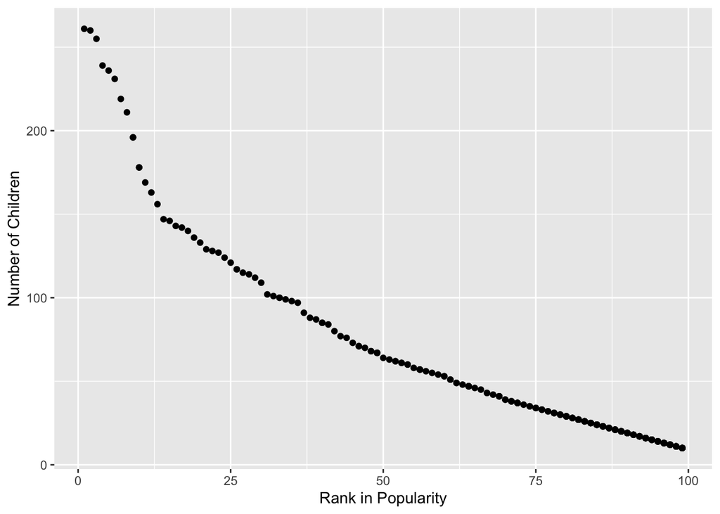

```r
white_male_2016_data =
  filter(names_data,ethnicity=="WHITE NON HISPANIC",year_of_birth==2016,gender=="MALE") %>%
  select(count,rank,name=childs_first_name)

ggplot(white_male_2016_data, aes(x=rank, y=count)) +
  geom_point()+
  # geom_text(aes(label=name),size = 1, vjust = -5) +
  xlab("Rank in Popularity") +
  ylab("Number of Children")
```